# Practical Machine Learning Course Project - Coursera

### Executive summary

In this document we explore the Human Activity Recognition (HAR) dataset (http://web.archive.org/web/20161224072740/http:/groupware.les.inf.puc-rio.br/har). This dataset contains data from accelerometers on the belt, forearm, arm, and dumbell of 6 participants. They were asked to perform barbell lifts correctly and incorrectly in 5 different ways. We try to predict the manner in which the participants performed the excercise based on this data. The models that we try are: Naive Bayes, Random Forest, and Support Vector Machines (SVM). We try models with only gyroscopic features, as we hypothesise that these say a lot about the manner in which the excersise was performed. Also we try models with all features included. We find the Random Forest model to outperform the others, with a 90% accuracy with only the gyroscopic features and 99% accuracy with all features.

## Part 1 - Data exploration

#### 0. Load libraries

#### 1 Load data

```r
df_train_path <- file.path(getwd(), "data", "pml-training.csv")
print(paste("Reading training data from:", df_train_path))
```

```
## [1] "Reading training data from: C:/Users/spanmandewit/Documents/02. Courses/01_Coursera_DataScience/08. Practial Machine Learning/project/data/pml-training.csv"
```

```r
df_train <- read.csv(df_train_path)
#head(df_train, 5)

df_test_path <- file.path(getwd(), "data", "pml-testing.csv")
print(paste("Reading testing data from:", df_test_path))
```

```
## [1] "Reading testing data from: C:/Users/spanmandewit/Documents/02. Courses/01_Coursera_DataScience/08. Practial Machine Learning/project/data/pml-testing.csv"
```

```r
df_test <- read.csv(df_test_path)
#head(df_test, 5)

print(paste("Number of rows in training data:", nrow(df_train)))
```

```
## [1] "Number of rows in training data: 19622"
```

```r
print(paste("Number of cols in training data:", length(names(df_train))))
```

```
## [1] "Number of cols in training data: 160"
```

```r
print(paste("Number of rows in test data    :", nrow(df_test)))
```

```
## [1] "Number of rows in test data    : 20"
```

```r
print(paste("Number of cols in test data    :", length(names(df_test))))
```

```
## [1] "Number of cols in test data    : 160"
```

```r
# Merge two dataframes
df_test$classe <- NA
df_train$problem_id <- NA
df_train$dataset <- "training"
df_test$dataset <- "test"

df <- rbind(df_train, df_test)
#head(df)
```

#### 2. Check column types

```r
num_cols <- names(df)[sapply(df, is.numeric)]
integer_cols <- names(df)[sapply(df, is.integer)]
factor_cols <- names(df)[sapply(df, is.factor)]

print("Numeric columns:")
```

```
## [1] "Numeric columns:"
```

```r
print(num_cols)
```

```
##   [1] "X"                        "raw_timestamp_part_1"
##   [3] "raw_timestamp_part_2"     "num_window"
##   [5] "roll_belt"                "pitch_belt"
##   [7] "yaw_belt"                 "total_accel_belt"
##   [9] "max_roll_belt"            "max_picth_belt"
##  [11] "min_roll_belt"            "min_pitch_belt"
##  [13] "amplitude_roll_belt"      "amplitude_pitch_belt"
##  [15] "var_total_accel_belt"     "avg_roll_belt"
##  [17] "stddev_roll_belt"         "var_roll_belt"
##  [19] "avg_pitch_belt"           "stddev_pitch_belt"
##  [21] "var_pitch_belt"           "avg_yaw_belt"
##  [23] "stddev_yaw_belt"          "var_yaw_belt"
##  [25] "gyros_belt_x"             "gyros_belt_y"
##  [27] "gyros_belt_z"             "accel_belt_x"
##  [29] "accel_belt_y"             "accel_belt_z"
```

[output cut: 47 more lines]

```r
print("Integer columns:")
```

```
## [1] "Integer columns:"
```

```r
print(integer_cols)
```

```
##  [1] "X"                    "raw_timestamp_part_1" "raw_timestamp_part_2"
##  [4] "num_window"           "total_accel_belt"     "max_picth_belt"
##  [7] "min_pitch_belt"       "amplitude_pitch_belt" "accel_belt_x"
## [10] "accel_belt_y"         "accel_belt_z"         "magnet_belt_x"
## [13] "magnet_belt_y"        "magnet_belt_z"        "total_accel_arm"
## [16] "accel_arm_x"          "accel_arm_y"          "accel_arm_z"
## [19] "magnet_arm_x"         "magnet_arm_y"         "magnet_arm_z"
## [22] "max_yaw_arm"          "min_yaw_arm"          "amplitude_yaw_arm"
## [25] "total_accel_dumbbell" "accel_dumbbell_x"     "accel_dumbbell_y"
## [28] "accel_dumbbell_z"     "magnet_dumbbell_x"    "magnet_dumbbell_y"
## [31] "total_accel_forearm"  "accel_forearm_x"      "accel_forearm_y"
## [34] "accel_forearm_z"      "magnet_forearm_x"     "problem_id"
```

```r
print("Factor columns:")
```

```
## [1] "Factor columns:"
```

```r
print(factor_cols)
```

```
##  [1] "user_name"               "cvtd_timestamp"
##  [3] "new_window"              "kurtosis_roll_belt"
##  [5] "kurtosis_picth_belt"     "kurtosis_yaw_belt"
##  [7] "skewness_roll_belt"      "skewness_roll_belt.1"
##  [9] "skewness_yaw_belt"       "max_yaw_belt"
## [11] "min_yaw_belt"            "amplitude_yaw_belt"
## [13] "kurtosis_roll_arm"       "kurtosis_picth_arm"
## [15] "kurtosis_yaw_arm"        "skewness_roll_arm"
## [17] "skewness_pitch_arm"      "skewness_yaw_arm"
## [19] "kurtosis_roll_dumbbell"  "kurtosis_picth_dumbbell"
## [21] "kurtosis_yaw_dumbbell"   "skewness_roll_dumbbell"
## [23] "skewness_pitch_dumbbell" "skewness_yaw_dumbbell"
## [25] "max_yaw_dumbbell"        "min_yaw_dumbbell"
## [27] "amplitude_yaw_dumbbell"  "kurtosis_roll_forearm"
## [29] "kurtosis_picth_forearm"  "kurtosis_yaw_forearm"
## [31] "skewness_roll_forearm"   "skewness_pitch_forearm"
## [33] "skewness_yaw_forearm"    "max_yaw_forearm"
## [35] "min_yaw_forearm"         "amplitude_yaw_forearm"
## [37] "classe"
```

Some columns are set as a factor, though they are numeric. Let’s fix that before exploring the data further. Also timestamp is not read well. Let’s also fix that.

#### 3. Fix columnn types

```r
non_feature_cols <- c("X", "user_name", "raw_timestamp_part_1", "raw_timestamp_part_2", "cvtd_timestamp", "new_window", "problem_id", "classe", "dataset")
feature_cols <- setdiff(names(df), non_feature_cols)
factor_cols_to_fix <- factor_cols[!(factor_cols %in% non_feature_cols)]
df[factor_cols_to_fix] <- lapply(df[factor_cols_to_fix], as.numeric)
df$raw_timestamp_part_1 <- as_datetime(df$raw_timestamp_part_1)
df$raw_timestamp_part_2 <- df$raw_timestamp_part_1 + df$raw_timestamp_part_2
df$raw_timestamp_part_2 <- as_datetime(df$raw_timestamp_part_2)
df$cvtd_timestamp <- as_datetime(as.character(df$cvtd_timestamp), format = "%d/%m/%Y %H:%M")
```

Before exploring, let’s delete columns that we are not going to use anyway. These are columns that either i) contain a lot of NA values, or ii) contain almost no variance in the data.

#### 4. Delete irrelevant columns

```r
# Delete columns where we have too little data (Less than 10% of the rows)
na_perc_per_col <-sapply(df, function(y) sum(length(which(is.na(y)))) / length(y))
old_ncol = ncol(df)

non_feature_cols_mask <- names(df) %in% non_feature_cols
df <- df[, na_perc_per_col < .1 | non_feature_cols_mask]
feature_cols <- intersect(feature_cols, names(df))

print(paste("Columns deleted:", old_ncol - ncol(df), "because those columns contain more than 90% NA values"))
```

```
## [1] "Columns deleted: 67 because those columns contain more than 90% NA values"
```

```r
print(paste("Columns left:", ncol(df)))
```

```
## [1] "Columns left: 95"
```

```r
# Delete columns with near zero values
nzv_cols <- names(df[feature_cols])[nearZeroVar(df[feature_cols])]
old_ncol = ncol(df)
df <- subset(df, select = !names(df) %in% nzv_cols)
feature_cols <- intersect(feature_cols, names(df))
print(paste("Columns deleted:", old_ncol - ncol(df) ))
```

```
## [1] "Columns deleted: 33"
```

```r
print(paste("Columns left:", ncol(df)))
```

```
## [1] "Columns left: 62"
```

```r
# Delete rows with any NAs
old_nrow <- nrow(df)
df[feature_cols] <- na.omit(df[feature_cols])
print(paste("Deleted:", old_nrow - nrow(df), "rows because they contain some NAs"))
```

```
## [1] "Deleted: 0 rows because they contain some NAs"
```

```r
df_train <- df[df$dataset=="training",]
df_test <- df[df$dataset=="test",]
```

## Part 2 - Data preparation

```r
dt_train <- as.data.table(df_train)
dt_test <- as.data.table(df_test)
dt <- as.data.table(df)

rm(df_train)
rm(df_test)
rm(df)
```

### Part 3 - Modelling with only gyroscope features

#### 1. Train models

```r
# Select features
selected_feature_cols <- feature_cols
gyro_cols_bools <- sapply(feature_cols, function(x) startsWith(x, "gyro"))
selected_feature_cols <- feature_cols[gyro_cols_bools]

# Create train and test vectors
X_train <- dt_train[, ..selected_feature_cols]
y_train <- dt_train$classe
X_test <- dt_test[, ..selected_feature_cols]
y_test <- dt_test$classe

# Define some variables
seed <- 7
set.seed(seed)
metric <- "Accuracy"

# Train models
control <- trainControl(method="cv", number=4, verboseIter = FALSE)
tunegrid <- expand.grid(.mtry=c(1:5))

# Models were already ran and saved to disk, so loading instead
#rf <- train(X_train, y_train, method="rf", metric=metric, tuneGrid=tunegrid, trControl=control)
#nb = train(X_train, y_train,'nb', trControl=trainControl(method='cv',number=4))
#svm = train(X_train, y_train,'svmLinear', trControl=trainControl(method='cv',number=4))
rf <- readRDS("./rf_gyros_feats.rds")
nb <- readRDS("./nb_gyros_feats.rds")
svm <- readRDS("./svm_gyros_feats.rds")
```

```r
print(nb)
```

```
## Naive Bayes
##
## 19622 samples
##    12 predictor
##     5 classes: 'A', 'B', 'C', 'D', 'E'
##
## No pre-processing
## Resampling: Cross-Validated (4 fold)
## Summary of sample sizes: 14718, 14716, 14715, 14717
## Resampling results across tuning parameters:
##
##   usekernel  Accuracy   Kappa
##   FALSE      0.3489487  0.1956179
##    TRUE      0.4590797  0.2764388
##
## Tuning parameter 'fL' was held constant at a value of 0
## Tuning
##  parameter 'adjust' was held constant at a value of 1
## Accuracy was used to select the optimal model using the largest value.
## The final values used for the model were fL = 0, usekernel = TRUE
##  and adjust = 1.
```

```r
print(rf)
```

```
## Random Forest
##
## 19622 samples
##    12 predictor
##     5 classes: 'A', 'B', 'C', 'D', 'E'
##
## No pre-processing
## Resampling: Cross-Validated (4 fold)
## Summary of sample sizes: 14717, 14716, 14716, 14717
## Resampling results across tuning parameters:
##
##   mtry  Accuracy   Kappa
##   1     0.8953724  0.8670472
##   2     0.9029148  0.8768254
##   3     0.9014879  0.8750670
##   4     0.8999590  0.8731647
##   5     0.8978188  0.8704508
##
## Accuracy was used to select the optimal model using the largest value.
## The final value used for the model was mtry = 2.
```

```r
print(svm)
```

```
## Support Vector Machines with Linear Kernel
##
## 19622 samples
##    12 predictor
##     5 classes: 'A', 'B', 'C', 'D', 'E'
##
## No pre-processing
## Resampling: Cross-Validated (4 fold)
## Summary of sample sizes: 14716, 14716, 14717, 14717
## Resampling results:
##
##   Accuracy   Kappa
##   0.3020077  0.02905289
##
## Tuning parameter 'C' was held constant at a value of 1
```

#### 2. Test models

```r
# Test models (not possible to get results as we don't have the labels)
#rf_pred <-predict(rf, dt_test)
#rf_cm <- confusionMatrix(rf_pred, dt_test$classe,  mode = "prec_recall")
#nb_pred <-predict(nb, dt_test)
#nb_cm <- confusionMatrix(nb_pred, dt_test$classe, mode = "prec_recall")
#svm_pred <-predict(svm, dt_test)
#svm_cm <- confusionMatrix(svm_pred, dt_test$classe,  mode = "prec_recall")
```

#### 3. Save results

```r
# Save results
train_accuracies <- c(max(rf$results$Accuracy), max(nb$results$Accuracy), svm$results$Accuracy)
model1_results  <- data.frame("classifier" = c("rf", "nb", "svm"), "train_accuracy"= train_accuracies)
model1_results$description <- "gyro_features"
model1_results$n_features <- length(selected_feature_cols)
saveRDS(rf, "./rf_gyros_feats.rds")
saveRDS(nb, "./nb_gyros_feats.rds")
saveRDS(svm, "./svm_gyros_feats.rds")

rm(rf)
rm(nb)
rm(svm)

model1_results
```

```
##   classifier train_accuracy   description n_features
## 1         rf      0.9029148 gyro_features         12
## 2         nb      0.4590797 gyro_features         12
## 3        svm      0.3020077 gyro_features         12
```

### Part 3 - Modelling with all features

#### 1. Train models

```r
# Select features
selected_feature_cols <- feature_cols

# Create train and test vectors
X_train <- dt_train[, ..selected_feature_cols]
y_train <- dt_train$classe
X_test <- dt_test[, ..selected_feature_cols]
y_test <- dt_test$classe

# Define some variables
seed <- 7
set.seed(seed)
metric <- "Accuracy"

## Models were already trained, loading from disk instead
# Train models
#control <- trainControl(method="cv", number=4, verboseIter = FALSE)
#tunegrid <- expand.grid(.mtry=c(5:10))
#rf <- train(X_train, y_train, method="rf", metric=metric, tuneGrid=tunegrid, trControl=control)
#nb = train(X_train, y_train,'nb', trControl=trainControl(method='cv',number=4))
#svm = train(X_train, y_train,'svmLinear', trControl=trainControl(method='cv',number=4))

rf <- readRDS("./rf_all_feats.rds")
nb <- readRDS("./nb_all_feats.rds")
svm <- readRDS("./svm_all_feats.rds")
```

```r
print(nb)
```

```
## Naive Bayes
##
## 19622 samples
##    53 predictor
##     5 classes: 'A', 'B', 'C', 'D', 'E'
##
## No pre-processing
## Resampling: Cross-Validated (4 fold)
## Summary of sample sizes: 14716, 14717, 14717, 14716
## Resampling results across tuning parameters:
##
##   usekernel  Accuracy   Kappa
##   FALSE      0.5051456  0.3874756
##    TRUE      0.7585366  0.6927457
##
## Tuning parameter 'fL' was held constant at a value of 0
## Tuning
##  parameter 'adjust' was held constant at a value of 1
## Accuracy was used to select the optimal model using the largest value.
## The final values used for the model were fL = 0, usekernel = TRUE
##  and adjust = 1.
```

```r
print(rf)
```

```
## Random Forest
##
## 19622 samples
##    53 predictor
##     5 classes: 'A', 'B', 'C', 'D', 'E'
##
## No pre-processing
## Resampling: Cross-Validated (4 fold)
## Summary of sample sizes: 14717, 14716, 14716, 14717
## Resampling results across tuning parameters:
##
##   mtry  Accuracy   Kappa
##    5    0.9971461  0.9963902
##    6    0.9974519  0.9967769
##    7    0.9976048  0.9969703
##    8    0.9977577  0.9971637
##    9    0.9979106  0.9973571
##   10    0.9979106  0.9973571
##
## Accuracy was used to select the optimal model using the largest value.
## The final value used for the model was mtry = 9.
```

```r
print(svm)
```

```
## Support Vector Machines with Linear Kernel
##
## 19622 samples
##    53 predictor
##     5 classes: 'A', 'B', 'C', 'D', 'E'
##
## No pre-processing
## Resampling: Cross-Validated (4 fold)
## Summary of sample sizes: 14716, 14716, 14716, 14718
## Resampling results:
##
##   Accuracy   Kappa
##   0.7898272  0.732897
##
## Tuning parameter 'C' was held constant at a value of 1
```

#### 2. Test models

```r
# Test models (not possible to get results as we don't have the labels)
#rf_pred <-predict(rf, dt_test)
#rf_cm <- confusionMatrix(rf_pred, dt_test$classe,  mode = "prec_recall")
#nb_pred <-predict(nb, dt_test)
#nb_cm <- confusionMatrix(nb_pred, dt_test$classe, mode = "prec_recall")
#svm_pred <-predict(svm, dt_test)
#svm_cm <- confusionMatrix(svm_pred, dt_test$classe,  mode = "prec_recall")
```

#### 3. Save results

```r
# Save results
train_accuracies <- c(max(rf$results$Accuracy), max(nb$results$Accuracy), max(svm$results$Accuracy))
model2_results  <- data.frame("classifier" = c("rf", "nb", "svm"), "train_accuracy"= train_accuracies)
model2_results$description <- "all_features"
model2_results$n_features <- length(selected_feature_cols)

saveRDS(rf, "./rf_all_feats.rds")
saveRDS(nb, "./nb_all_feats.rds")
saveRDS(svm, "./svm_all_feats.rds")
```

### Part 4 - Evaluation

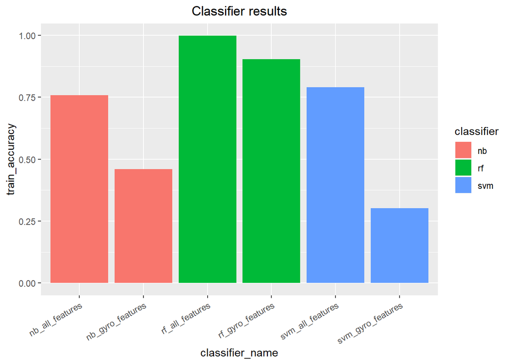

```r
model_results <- rbind(model1_results, model2_results)
model_results$classifier_name <- paste(model_results$classifier, "_", model_results$description, sep = "")

ggplot(model_results, aes(x=classifier_name, y = train_accuracy, fill = classifier)) +
  geom_bar( stat = "identity") +
  theme(plot.title = element_text(hjust = 0.5), axis.text.x = element_text(angle = 30, hjust = 1)) +
  labs(title="Classifier results")
```

We can see that the Random Forest performs the best with an accuracy of 99% on the training set.